# SVM & Clustering

INFO 521 · Module 6 · Lecture A — Maximum-Margin Classification

Greg Chism

College of Information Science · University of Arizona

August 2026

## Learning outcomes

By the end of Lecture A you should be able to:

1. **State the maximum-margin idea** and define **support vectors**.
2. **Compare the hinge loss to the logistic loss** — same boundary family, different priorities.
3. **Explain the kernel idea** at concept level — nonlinearity without leaving linear machinery.
4. **Evaluate a classifier honestly** — beyond accuracy, at 38.8% prevalence.

## One boundary, three philosophies

Module 5 fit $p(y \mid \mathbf{x})$ and took its $\tfrac{1}{2}$-contour as the boundary. But if **the boundary is all you want**, why model probabilities at all?

- **Logistic** — model the probability; the boundary falls out.
- **Bayes-posterior** — model belief over $\mathbf{w}$; average boundaries.
- **Max-margin** — *skip the probabilities*: choose the boundary directly, by a geometric criterion.

Third act of the course, same linear score $\mathbf{w}^{\!\top}\mathbf{x}$ — what changes is **what we optimize**.

## The maximum-margin idea

Many hyperplanes separate the classes. Prefer the one **farthest from both**:

$$\max_{\mathbf{w}, b}\ \ \frac{2}{\lVert\mathbf{w}\rVert}
\qquad \text{s.t.} \qquad
y_n\left(\mathbf{w}^{\!\top}\mathbf{x}_n + b\right) \ge 1 \quad \forall n,
\qquad y_n \in \{-1, +1\}$$

- The **margin** $2/\lVert\mathbf{w}\rVert$ is the empty corridor around the boundary; maximizing it = minimizing $\lVert\mathbf{w}\rVert^2$ — a **norm penalty as the *objective***, ridge’s cousin (m2b).
- Only the points **on the corridor’s edge** constrain the answer — the **support vectors**. Delete any other point: nothing moves.

## The margin, drawn

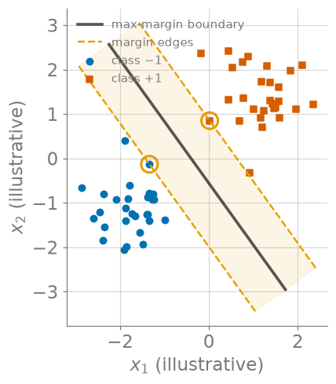

Figure 1: Maximum margin (illustrative 2-D data): the boundary keeps the widest empty corridor; only the circled support vectors hold it up.

## Real data isn’t separable: the hinge loss

NHANES ages overlap heavily across hypertension status — no empty corridor exists. **Soft-margin** SVM lets points buy their way in, at a price:

$$\min_{\mathbf{w}, b}\ \
\underbrace{\sum_{n=1}^{N}\max\!\bigl(0,\ 1 - y_n(\mathbf{w}^{\!\top}\mathbf{x}_n + b)\bigr)}_{\text{hinge loss}}
\;+\; \lambda \lVert\mathbf{w}\rVert^2$$

- Inside-or-wrong-side points pay **linearly**; comfortable points pay **exactly zero**.
- Loss + norm penalty: the ridge template (m2b), with hinge in place of squares.
- $\lambda$ trades margin width against violations — tuned by CV (m2a), as ever.

## Hinge vs. logistic: what each loss cares about

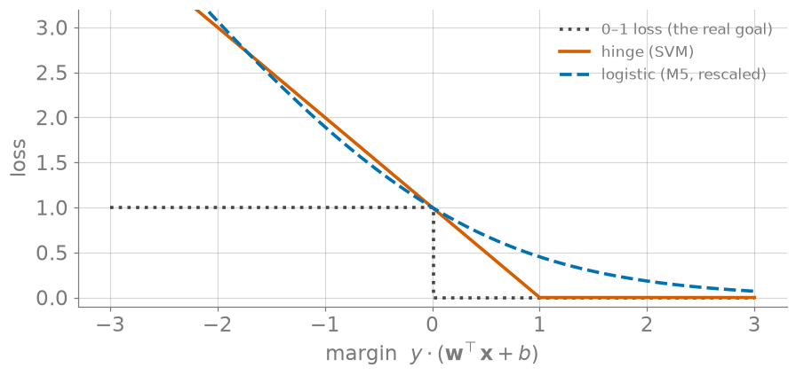

Figure 2: Three losses vs. the margin y·a: hinge (kinked, exactly 0 past 1) vs. logistic (smooth, never 0) vs. the 0–1 loss both surrogate.

- **Hinge**: ignores comfortable points entirely → *sparse* (support vectors), no probabilities.
- **Logistic**: every point always pays a little → calibrated $p(y\mid\mathbf{x})$, no sparsity.

## Kernels, at concept level

Linear boundaries fail when the truth is curved. Old fix (m1b): map to features $\boldsymbol{\phi}(\mathbf{x})$ and stay linear *in the weights*.

**Kernel observation**: max-margin training touches inputs only through inner products — so it needs only

$$k(\mathbf{x}, \mathbf{x}')
= \boldsymbol{\phi}(\mathbf{x})^{\!\top}\boldsymbol{\phi}(\mathbf{x}')$$

- Choose $k$ **directly** (polynomial, Gaussian/RBF, …) and never build $\boldsymbol{\phi}$ — even when it is infinite-dimensional.
- The boundary becomes a weighted sum of kernels **on the support vectors** — flexibility priced per support vector, not per dimension.

Basis functions (m1b) walked so kernels could run — same move, industrialized.

## Evaluating classifiers at 38.8% prevalence

NHANES hypertension prevalence is $\approx 0.388$ — so **“nobody is hypertensive” scores 61% accuracy** while missing every case. Accuracy alone is a rigged scoreboard.

|  | predicted + | predicted − |
| --- | --- | --- |
| **actually +** | TP | FN *(missed cases — the costly cell)* |
| **actually −** | FP | TN |

- **Sensitivity / recall** $= \mathrm{TP}/(\mathrm{TP}{+}\mathrm{FN})$ — of the hypertensive, how many did we catch?
- **Precision** $= \mathrm{TP}/(\mathrm{TP}{+}\mathrm{FP})$ — of our alarms, how many were real?
- Margin methods output scores; **where you cut the score** sets the sensitivity/precision trade — a *clinical* choice, not a mathematical one.

## Recap & the unsupervised turn

- **Max-margin**: widest corridor; held up by **support vectors** only.
- **Hinge vs. logistic**: sparsity + geometry vs. probabilities + calibration — same linear score, different contract.
- **Kernels**: inner products only ⇒ nonlinear boundaries with linear machinery.
- **Evaluation**: at 38.8% prevalence, report sensitivity/precision, not accuracy.

**Next (Lecture B):** drop the labels entirely. What structure lives in the features alone — and what happens when we *pretend* clusters are diagnoses?